# Plotting and Visualization

### Colors, Markers, and Line Styles

ax.plot(x, y, 'g--')

ax.plot(x, y, linestyle='--', color='g')

```python
plt.figure()
```

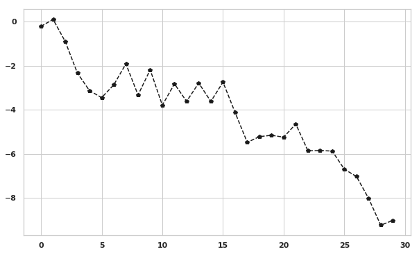

```python
from numpy.random import randn
plt.plot(randn(30).cumsum(), 'kp--')
```

```python
plt.close('all')
```

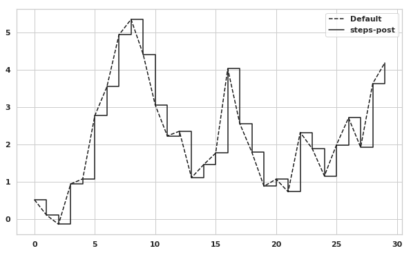

```python
data = np.random.randn(30).cumsum()
plt.plot(data, 'k--', label='Default')
plt.plot(data, 'k-', drawstyle='steps-post', label='steps-post')
plt.legend(loc='best')
```

### Ticks, Labels, and Legends

#### Setting the title, axis labels, ticks, and ticklabels

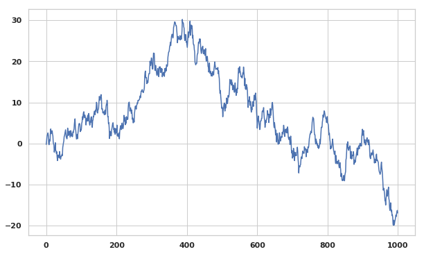

```python
fig = plt.figure()
ax = fig.add_subplot(1, 1, 1)
ax.plot(np.random.randn(1000).cumsum())
```

```python
ticks = ax.set_xticks([0, 250, 500, 750, 1000])
labels = ax.set_xticklabels(['one', 'two', 'three', 'four', 'five'],
                            rotation=30, fontsize='small')
```

```python
ax.set_title('My first matplotlib plot')
ax.set_xlabel('Stages')

ax.plot(np.random.randn(1000).cumsum())
```

props = { 'title': 'My first matplotlib plot', 'xlabel': 'Stages' } ax.set(**props)

#### Adding legends

```
No handles with labels found to put in legend.
```

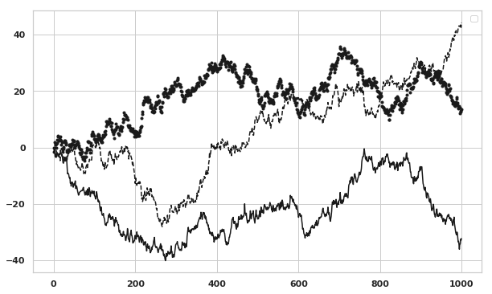

```python
from numpy.random import randn
fig = plt.figure()
ax = fig.add_subplot(1, 1, 1)
ax.legend(loc='best')
ax.plot(randn(1000).cumsum(), 'k', label='one')
ax.plot(randn(1000).cumsum(), 'k--', label='two')
ax.plot(randn(1000).cumsum(), 'k.', label='three')
```

### Annotations and Drawing on a Subplot

ax.text(x, y, 'Hello world!', family='monospace', fontsize=10)

```
Text(2007-10-11 00:00:00, 1779.41, 'Peak of bull market')
```

```
Text(2008-03-12 00:00:00, 1533.77, 'Bear Stearns Fails')
```

```
Text(2008-09-15 00:00:00, 1417.7, 'Lehman Bankruptcy')
```

```
(732677.0, 734138.0)
```

```
(600, 1800)
```

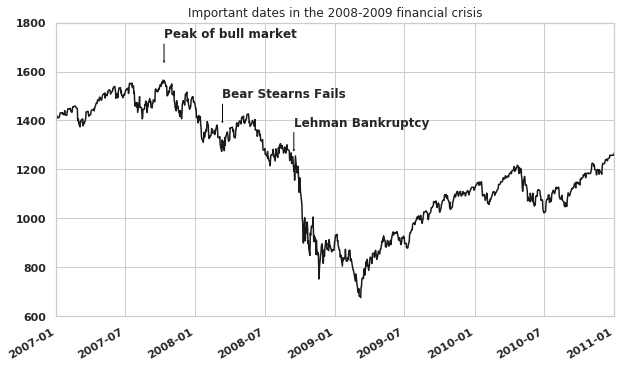

```python
from datetime import datetime

fig = plt.figure()
ax = fig.add_subplot(1, 1, 1)

data = pd.read_csv('examples/spx.csv', index_col=0, parse_dates=True)
spx = data['SPX']

spx.plot(ax=ax, style='k-')

crisis_data = [
    (datetime(2007, 10, 11), 'Peak of bull market'),
    (datetime(2008, 3, 12), 'Bear Stearns Fails'),
    (datetime(2008, 9, 15), 'Lehman Bankruptcy')
]

for date, label in crisis_data:
    ax.annotate(label, xy=(date, spx.asof(date) + 75),
                xytext=(date, spx.asof(date) + 225),
                arrowprops=dict(facecolor='black', headwidth=4, width=2,
                                headlength=4),
                horizontalalignment='left', verticalalignment='top')

# Zoom in on 2007-2010
ax.set_xlim(['1/1/2007', '1/1/2011'])
ax.set_ylim([600, 1800])

ax.set_title('Important dates in the 2008-2009 financial crisis')
```

```python
ax.set_title('Important dates in the 2008–2009 financial crisis')
```

fig = plt.figure() ax = fig.add_subplot(1, 1, 1)

rect = plt.Rectangle((0.2, 0.75), 0.4, 0.15, color='k', alpha=0.3) circ = plt.Circle((0.7, 0.2), 0.15, color='b', alpha=0.3) pgon = plt.Polygon([[0.15, 0.15], [0.35, 0.4], [0.2, 0.6]], color='g', alpha=0.5)

ax.add_patch(rect) ax.add_patch(circ) ax.add_patch(pgon)

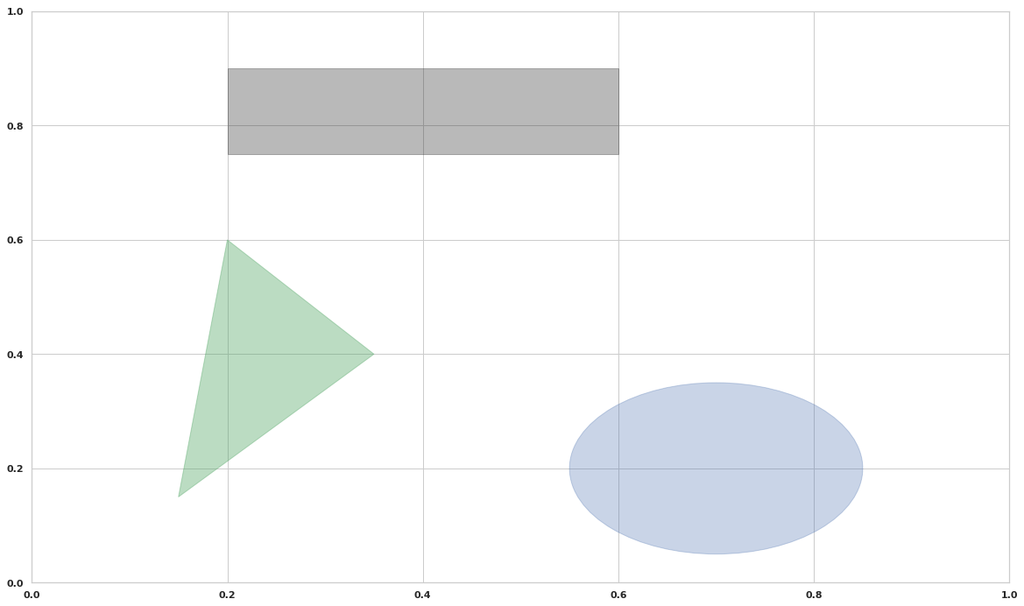

```python
fig = plt.figure(figsize=(20, 12)); ax = fig.add_subplot(1, 1, 1)
rect = plt.Rectangle((0.2, 0.75), 0.4, 0.15, color='k', alpha=0.3)
circ = plt.Circle((0.7, 0.2), 0.15, color='b', alpha=0.3)
pgon = plt.Polygon([[0.15, 0.15], [0.35, 0.4], [0.2, 0.6]],
                   color='g', alpha=0.4)
ax.add_patch(rect)
ax.add_patch(circ)
ax.add_patch(pgon)
```

### Saving Plots to File

```python
plt.savefig('figpath.svg')
```

```python
plt.savefig('figpath.png', dpi=400, bbox_inches='tight')
```

```python
from io import BytesIO
buffer = BytesIO()
plt.savefig(buffer)
plot_data = buffer.getvalue()
```

### matplotlib Configuration

```python
plt.rc('figure', figsize=(10, 10))
```

```python
font_options = {'family' : 'monospace',
                'weight' : 'bold',
                'size'   : 5.0}
plt.rc('font', **font_options)
```

## Plotting with pandas and seaborn

### Line Plots

```python
plt.close('all')
```

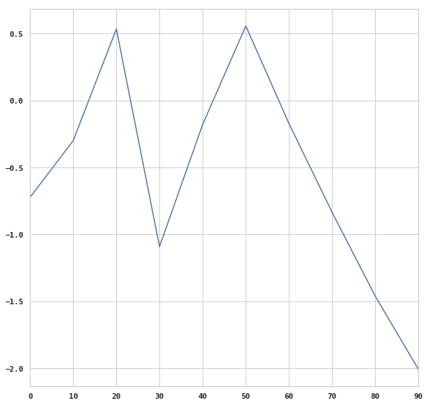

```python
s = pd.Series(np.random.randn(10).cumsum(), index=np.arange(0, 100, 10))
s.plot()
```

|  | A | B | C | D |
| --- | --- | --- | --- | --- |
| 0 | -0.129625 | -0.613615 | 2.221012 | 1.128388 |
| 10 | -2.258814 | -0.090403 | 0.818481 | -0.325249 |
| 20 | -0.560395 | -2.241242 | 2.113316 | -1.841294 |
| 30 | 1.222321 | -1.810830 | -0.099040 | -0.657660 |
| 40 | -0.413738 | -1.291370 | 0.465202 | 0.263391 |
| 50 | -1.619064 | -1.943371 | 1.828393 | 1.538724 |
| 60 | -2.299075 | -2.282506 | 0.960537 | 1.878348 |
| 70 | -1.690138 | -1.812095 | 0.112544 | 1.580091 |
| 80 | -0.357768 | 0.042349 | -0.075895 | 1.340912 |
| 90 | -0.796112 | 0.301559 | 1.573932 | 1.894547 |

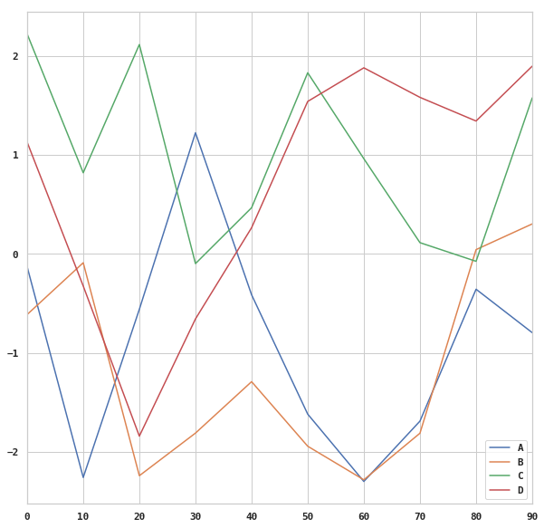

```python
df = pd.DataFrame(np.random.randn(10, 4).cumsum(0),
                  columns=['A', 'B', 'C', 'D'],
                  index=np.arange(0, 100, 10))
df
df.plot()
```

### Bar Plots

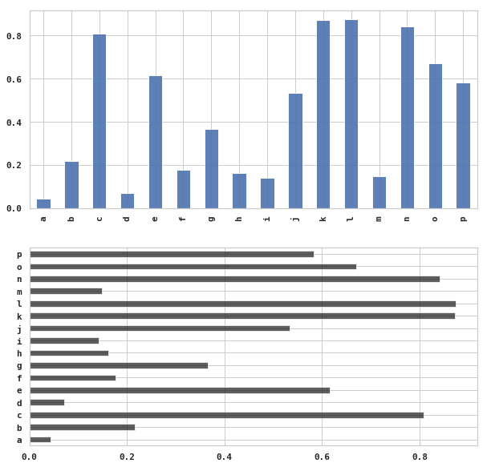

```python
fig, axes = plt.subplots(2, 1)
data = pd.Series(np.random.rand(16), index=list('abcdefghijklmnop'))
data.plot.bar(ax=axes[0], color='b', alpha=0.9)
data.plot.barh(ax=axes[1], color='k', alpha=0.7)
```

```python
np.random.seed(12348)
```

| Genus | A | B | C | D |
| --- | --- | --- | --- | --- |
| one | 0.370670 | 0.602792 | 0.229159 | 0.486744 |
| two | 0.420082 | 0.571653 | 0.049024 | 0.880592 |
| three | 0.814568 | 0.277160 | 0.880316 | 0.431326 |
| four | 0.374020 | 0.899420 | 0.460304 | 0.100843 |
| five | 0.433270 | 0.125107 | 0.494675 | 0.961825 |
| six | 0.601648 | 0.478576 | 0.205690 | 0.560547 |

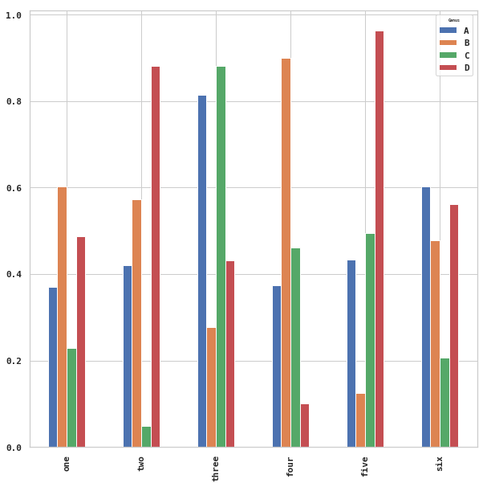

```python
df = pd.DataFrame(np.random.rand(6, 4),
                  index=['one', 'two', 'three', 'four', 'five', 'six'],
                  columns=pd.Index(['A', 'B', 'C', 'D'], name='Genus'))
df
df.plot.bar()
```

```python
plt.figure()
```

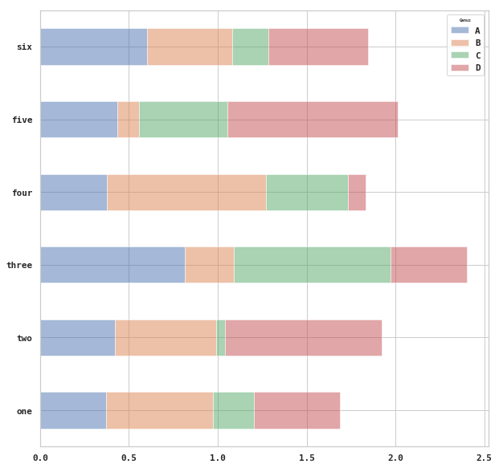

```python
df.plot.barh(stacked=True, alpha=0.5)
```

```python
plt.close('all')
```

```python
tips = pd.read_csv('examples/tips.csv')
party_counts = pd.crosstab(tips['day'], tips['size'])
party_counts
# Not many 1- and 6-person parties
party_counts = party_counts.loc[:, 2:5]
```

| size day | 1 | 2 | 3 | 4 | 5 | 6 |
| --- | --- | --- | --- | --- | --- | --- |
| Fri | 1 | 16 | 1 | 1 | 0 | 0 |
| Sat | 2 | 53 | 18 | 13 | 1 | 0 |
| Sun | 0 | 39 | 15 | 18 | 3 | 1 |
| Thur | 1 | 48 | 4 | 5 | 1 | 3 |

| size day | 2 | 3 | 4 | 5 |
| --- | --- | --- | --- | --- |
| Fri | 0.888889 | 0.055556 | 0.055556 | 0.000000 |
| Sat | 0.623529 | 0.211765 | 0.152941 | 0.011765 |
| Sun | 0.520000 | 0.200000 | 0.240000 | 0.040000 |
| Thur | 0.827586 | 0.068966 | 0.086207 | 0.017241 |

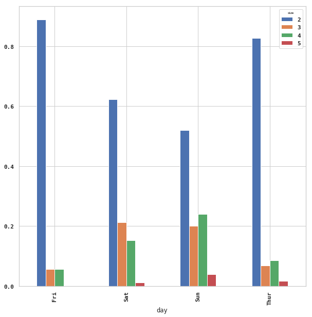

```python
# Normalize to sum to 1
party_pcts = party_counts.div(party_counts.sum(1), axis=0)
party_pcts
party_pcts.plot.bar()
```

```python
plt.close('all')
```

|  | total_bill | tip | smoker | day | time | size | tip_pct |
| --- | --- | --- | --- | --- | --- | --- | --- |
| 0 | 16.99 | 1.01 | No | Sun | Dinner | 2 | 0.063204 |
| 1 | 10.34 | 1.66 | No | Sun | Dinner | 3 | 0.191244 |
| 2 | 21.01 | 3.50 | No | Sun | Dinner | 3 | 0.199886 |
| 3 | 23.68 | 3.31 | No | Sun | Dinner | 2 | 0.162494 |
| 4 | 24.59 | 3.61 | No | Sun | Dinner | 4 | 0.172069 |

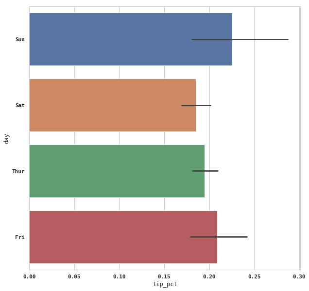

```python
import seaborn as sns
tips['tip_pct'] = tips['tip'] / (tips['total_bill'] - tips['tip'])
tips.head()
sns.barplot(x='tip_pct', y='day', data=tips, orient='h')
```

```python
plt.close('all')
```

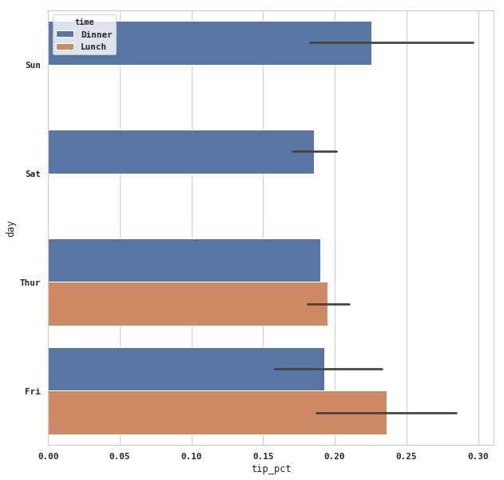

```python
sns.barplot(x='tip_pct', y='day', hue='time', data=tips, orient='h')
```

```python
plt.close('all')
```

```python
sns.set(style="whitegrid")
```

### Histograms and Density Plots

```python
plt.figure()
```

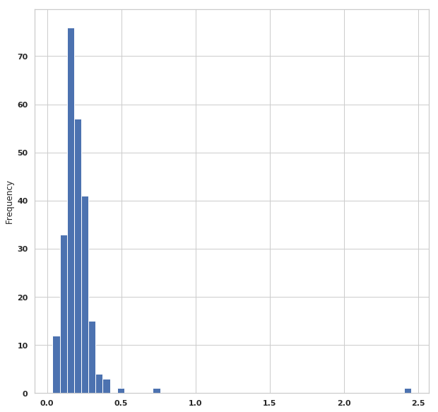

```python
tips['tip_pct'].plot.hist(bins=50)
```

```python
plt.figure()
```

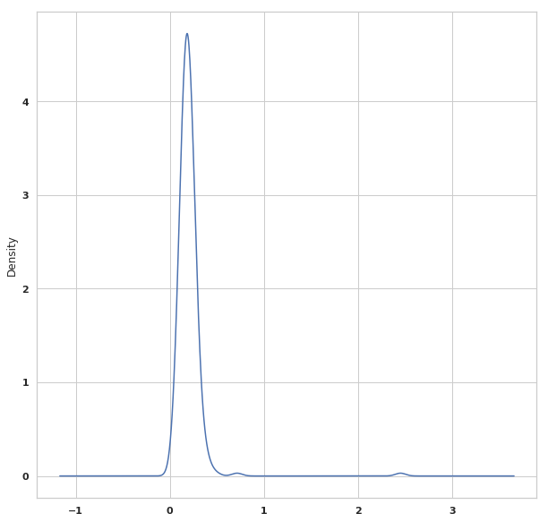

```python
tips['tip_pct'].plot.density()
```

```python
plt.figure()
```

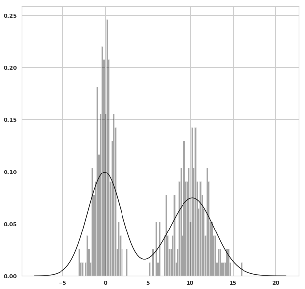

```python
comp1 = np.random.normal(0, 1, size=200)
comp2 = np.random.normal(10, 2, size=200)
values = pd.Series(np.concatenate([comp1, comp2]))
sns.distplot(values, bins=100, color='k')
```

### Scatter or Point Plots

```python
macro = pd.read_csv('examples/macrodata.csv')
data = macro[['cpi', 'm1', 'tbilrate', 'unemp']]
trans_data = np.log(data).diff().dropna()
trans_data[-5:]
```

|  | cpi | m1 | tbilrate | unemp |
| --- | --- | --- | --- | --- |
| 198 | -0.007904 | 0.045361 | -0.396881 | 0.105361 |
| 199 | -0.021979 | 0.066753 | -2.277267 | 0.139762 |
| 200 | 0.002340 | 0.010286 | 0.606136 | 0.160343 |
| 201 | 0.008419 | 0.037461 | -0.200671 | 0.127339 |
| 202 | 0.008894 | 0.012202 | -0.405465 | 0.042560 |

```python
plt.figure()
```

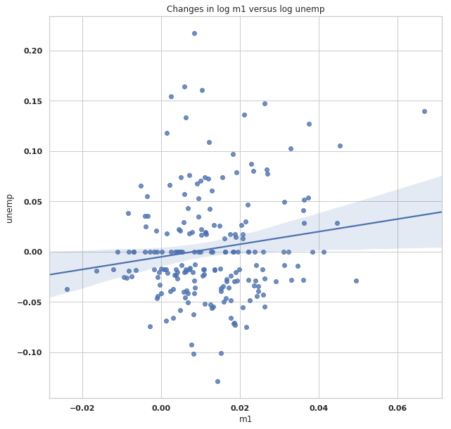

```python
sns.regplot('m1', 'unemp', data=trans_data)
plt.title('Changes in log %s versus log %s' % ('m1', 'unemp'))
```

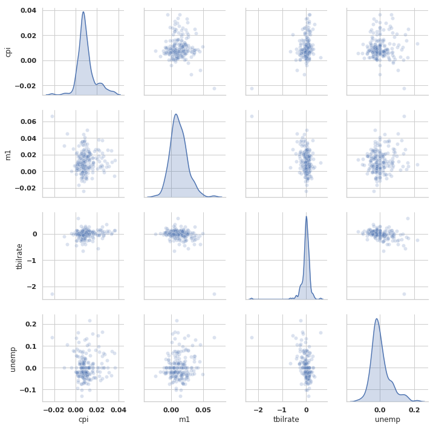

```python
sns.pairplot(trans_data, diag_kind='kde', plot_kws={'alpha': 0.2})
```

### Facet Grids and Categorical Data

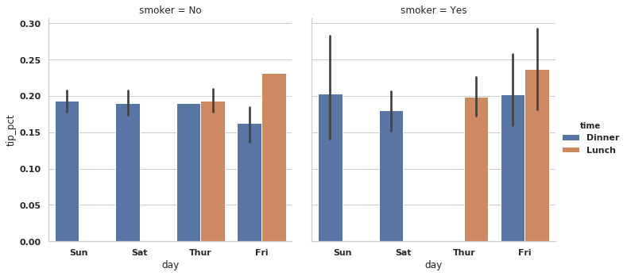

```python
sns.factorplot(x='day', y='tip_pct', hue='time', col='smoker',
               kind='bar', data=tips[tips.tip_pct < 1])
```

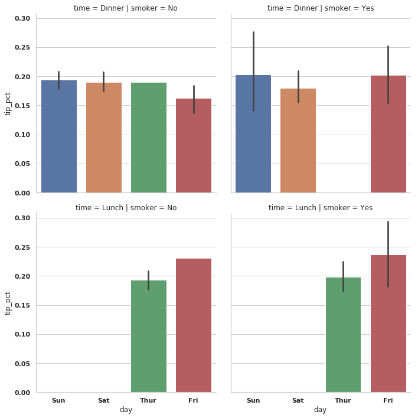

```python
sns.factorplot(x='day', y='tip_pct', row='time',
               col='smoker',
               kind='bar', data=tips[tips.tip_pct < 1])
```

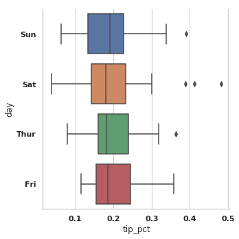

```python
sns.factorplot(x='tip_pct', y='day', kind='box',
               data=tips[tips.tip_pct < 0.5])
```

## Other Python Visualization Tools

```python
pd.options.display.max_rows = PREVIOUS_MAX_ROWS
```